# Analysis of activity data

Author: Anupama Gudipati

Date: “Sunday, January 18, 2015”

### Sample data:

Sample data can be downloaded from : https://d396qusza40orc.cloudfront.net/repdata%2Fdata%2Factivity.zip

The variables included in this dataset are:

steps: Number of steps taking in a 5-minute interval (missing values are coded as NA)

date: The date on which the measurement was taken in YYYY-MM-DD format

interval: Identifier for the 5-minute interval in which measurement was taken

The dataset is stored in a comma-separated-value (CSV) file and there are a total of 17,568 observations in this dataset.

Lets load and remove NAs from the data

```r
activity_data <- read.csv("activity.csv")
activity_data_rm_na <- activity_data[(!is.na(activity_data$steps)),]
```

### What is mean total number of steps taken per day?

Lets make a histogram of daily data

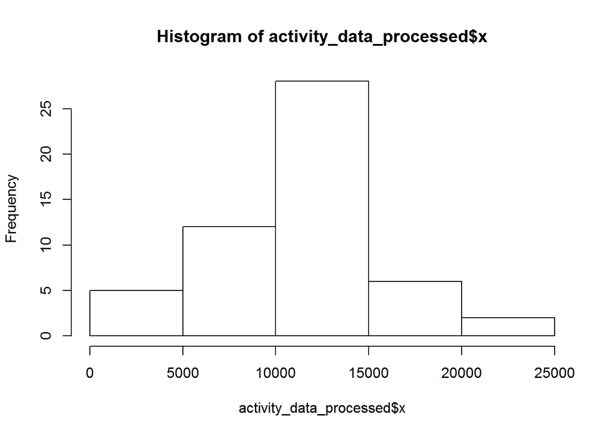

```r
activity_data_processed <-aggregate(activity_data_rm_na$steps, by=list(activity_data_rm_na$date), FUN=sum, na.rm=TRUE)
hist(activity_data_processed$x)
```

Lets see the mean and median of steps done eachday

```r
mean(activity_data_processed$x)
```

```
## [1] 10766.19
```

```r
median(activity_data_processed$x)
```

```
## [1] 10765
```

### What is the average daily activity pattern?

Let’s make a time series plot (i.e. type = “l”) of the 5-minute interval (x-axis) and the average number of steps taken, averaged across all days (y-axis)

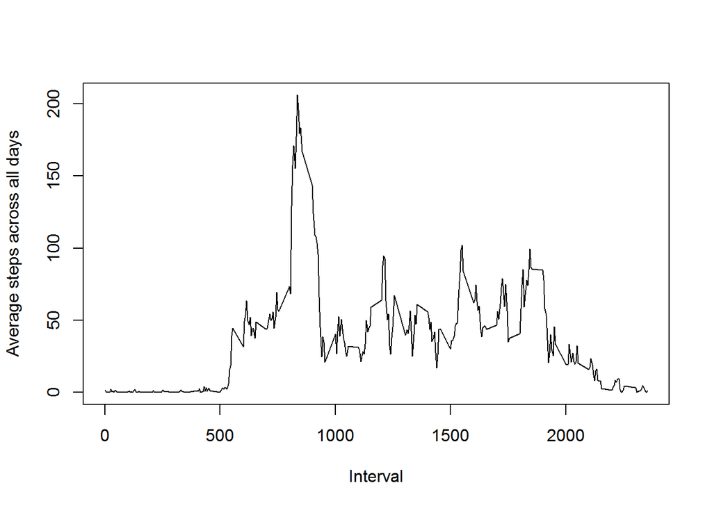

```r
avg_steps_interval <-aggregate(activity_data_rm_na$steps, by=list(activity_data_rm_na$interval), FUN=mean, na.rm=TRUE)
with(avg_steps_interval,plot(Group.1,x,type="l",xlab="Interval",ylab="Average steps across all days"))
```

Now lets see which interval has the maximum number of steps

```r
avg_steps_interval[which(avg_steps_interval$x==max(avg_steps_interval$x)),1]
```

```
## [1] 835
```

### Imputing missing values

It’s common to have NAs as part of any sample data. Lets see how many NAs we have:

```r
NACount<-nrow(activity_data[(is.na(activity_data$steps)),])
```

There are 2304 NAs in the sample dataset. Let’s impute the NAs with mean

```r
library("Hmisc")
library("plyr")
impute_activity_data <- activity_data
impute_activity_data$steps <- impute(activity_data$steps,mean)
```

Now lets analyze what differences does impute bring. Make a histogram of the total number of steps taken each day and Calculate and report the mean and median total number of steps taken per day.

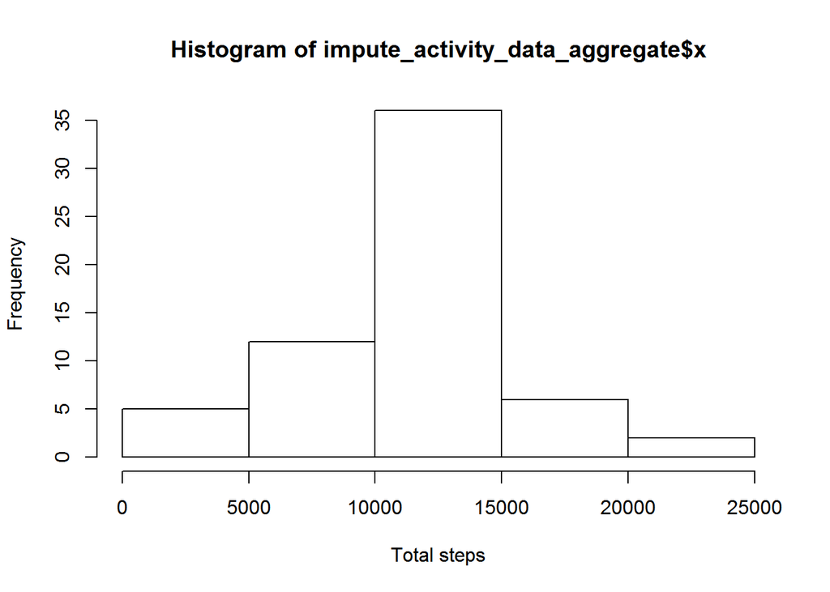

```r
impute_activity_data_aggregate <- aggregate(impute_activity_data$steps, by=list(impute_activity_data$date), FUN=sum, na.rm=TRUE)
hist(impute_activity_data_aggregate$x,xlab="Total steps")
```

```r
mean(impute_activity_data_aggregate$x)
```

```
## [1] 10766.19
```

```r
median(impute_activity_data_aggregate$x)
```

```
## [1] 10766.19
```

### Are there differences in activity patterns between weekdays and weekends?

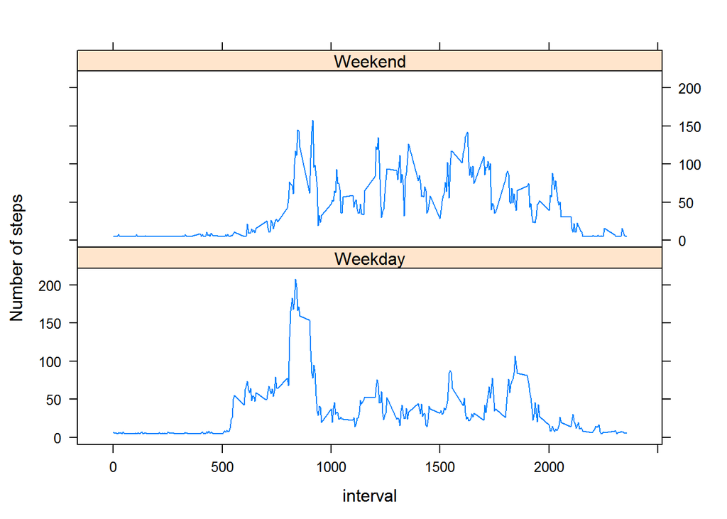

```r
impute_activity_data$wday <- as.factor(ifelse(weekdays(as.POSIXct(impute_activity_data$date)) %in% c("Saturday","Sunday"), "Weekend", "Weekday"))

avg_wday_steps<-aggregate(impute_activity_data$steps, by=list(Date=impute_activity_data$interval,impute_activity_data$wday),FUN=mean)
avg_wday_steps$x<-as.numeric(avg_wday_steps$x)


xyplot(x~Date|Group.2, data=avg_wday_steps,layout=c(1,2),type="l", xlab="interval",ylab="Number of steps")
```